# Sprawozdanie - Zadanie 3.5

Paulina Popiołek, Agnieszka Pszczółkowska

17 kwietnia 2017

# 1. Cel zadania

Celem poniższego sprawozdania jest przygotowanie statystyk jeżeli chodzi o czas rozwiązywania, liczbę podjętych akcji i wyniki dla zadań prezentowanych na pozycji 1/ 2/ 3/ 4 w podziale na kraje biorące udział w badaniu PISA. Dzięki uwzględnieniu kolejności rozwiązywania zadań możemy badać, jak zachowują się profile udzielania odpowiedzi/ czasu poświęconego poszczególnym grupom zadań, co zostało zwizualizowane w dalszej części sprawozdania.

# 2. Dane

Dla każdego państwa zostały wyznaczone statystyki dotyczące grup zadań znajdujących się na poszczególnych pozycjach (od 1 do 4) - ich wyników, czasu oraz liczby akcji. W podziale na kraj, rodzaj zadania (Matematyka, Czytanie ze Zrozumieniem, Nauki Przyrodnicze) oraz pozycję obliczone zostały: minimum, maksimum, mediana, mediana ważona oraz średnia ważona. Tak przygotowane dane znajdują się w pliku “stat_position.xlsx”.

| CNT | exercise | position | minresult | medresult_W | medresult | meanresult | maxresult | minActions | medActions | meanActions | maxActions | minTiming | medTiming_W | medTiming | meanTiming | maxTiming |
| --- | --- | --- | --- | --- | --- | --- | --- | --- | --- | --- | --- | --- | --- | --- | --- | --- |
| ARE | Matematyka | 1 | 0 | 0 | 0 | 0.83 | 2 | 1 | 5 | 10.95 | 1751 | 0.352 | 82.03728 | 82.0820 | 101.54 | 1270.317 |
| ARE | Matematyka | 2 | 0 | 0 | 0 | 0.78 | 2 | 1 | 5 | 9.16 | 1543 | 0.428 | 67.57404 | 67.6890 | 83.46 | 7767.883 |
| ARE | Matematyka | 3 | 0 | 0 | 0 | 0.77 | 2 | 1 | 5 | 9.89 | 1287 | 0.452 | 68.63712 | 67.5440 | 85.21 | 1563.457 |
| ARE | Matematyka | 4 | 0 | 0 | 0 | 0.77 | 2 | 0 | 5 | 9.31 | 2142 | 0.416 | 58.32032 | 57.5755 | 74.63 | 2618.568 |
| ARE | Czytanie ze zrozumieniem | 1 | 0 | 2 | 2 | 1.09 | 2 | 1 | 4 | 7.33 | 3895 | 0.439 | 49.81784 | 49.4875 | 69.52 | 1239.392 |

# 3. Wnioski

1. Niezależnie od rodzaju zadania, pytania znajdujące się w pierwszej części (pozycja = 1) zajmują uczniom najwięcej czasu, natomiast drugiej i czwartej części (pozycja = 2 i pozycja = 4) dzieci poświęcają mniej czasu.
2. Największe różnice między spadkiem czasu rozwiązywania zadań na pozycjach 1-2 oraz 3-4 niezależnie od rodzaju pytania osiągają państwa z niższych pozycji rankigu PISA 2015 - Brazyli, Peru i Meksyku, jednocześnie mając najgorsze średnie czasy.
3. Zdecydowanymi faworytami pozostają państwa azjatyckie - Korea i Hongkong, Japonia dołącza do nich w zadaniach z Matematyki. Ich wahania między spadkiem czasu rozwiązywania zadań na pozycjach 1-2 oraz 3-4 są niewielkie, ponadto rozwiązują zadania najszybciej.
4. Małe różnice między spadkiem czasu rozwiązywania zadań na pozycjach 1-2 oraz 3-4 nie zawsze idą w parze z niskimi średnimi czasami czego przykładem są Finlandia, Wielka Brytania oraz Kanada.
5. Niezależnie od pozycji, pod względem czasu, polskim uczniom najdalej jest do młodzieży krajów azjatyckich. Osiągamy lepsze czasy niż nasz południowy sąsiad - Czechy, jednak różnica ta maleje w trakcie testu. Natomiast dla zachodniego sąsiada, Niemiec, różnice są małe z jednym wyjątkiem - pozycji 3 na naszą niekorzyść.
6. Najszybciej na zadania odpowiadają uczniowie z państw azjatyckich, w połowie stawki plasują się kraje Europy, Ameryki Północnej i Australia, a najdłużej odpowiadają uczniowie z Ameryki Południowej.

# 4. Analiza

Analizę zaczęłyśmy od porównania rozkładów średniego czasu rozwiązywania zadań w zależności od pozycji zadania w arkuszu w podziale na rodzaj zadania (Matematyka, Czytanie ze Zrozumieniem, Nauki Przyrodnicze). Oczywiście do wizualizacji użyłyśmy wyznaczonych wcześniej statystyk opisanych w rozdziale 2.

W kolejnych punktach analizy, wizualizacje zostały wykonane dla wybranej grupy krajów. Są to: 1. Polska 2. Finlandia 3. Niemcy 4. Czechy 5. Włochy 6. Wielka Brytania 7. USA 8. Kanada 9. Japonia 10. Korea 11. Hong Kong 12. Peru 13. Brazylia 14. Meksyk 15. Austalia

## 4.1 Jak wygląda rozkład średniego czasu odpowiedzi na poszczególnych pozycjach?

Na wykresach poniżej widzimy od razu, że rozkład średniego czasu rozwiązywania zadań różni się znacząco w zależności od pozycji tego zadania w arkuszu. Niezależnie od rodzaju zadania, pytania znajdujące się w pierwszej części (pozycja = 1) zajmują uczniom najwięcej czasu, natomiast drugiej i czwartej części (pozycja = 2 i pozycja = 4) dzieci poświęcają najmniej czasu. Widoczna jest tu także zależność długości czasu od rodzaju zadania - zadania z matematyki są przez uczniów rozwiązywane znacząco dłużej niż zadania z przyrody czy czytania ze zrozumieniem. Ponadto widać, że w każdym przypadkum, najkrótsze średnie czasy rozwiązywania zadań mieli uczniowie z Korei, najdłuższe z Peru, natomiast Polska plasowała się mniej więcej w połowie stawki.

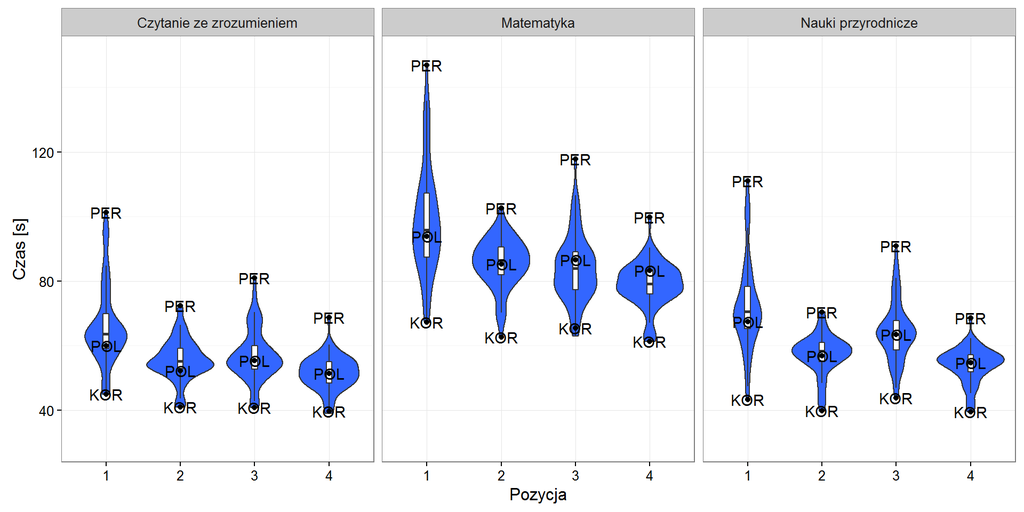

## 4.2 Który kraj najbardziej ulega presji czasu?

Wykonując wykresy analogiczne do tego z punktu 4.1 można zauważyć jednakową tendencję - uczniowe w pierwszej części testu rozwiązują go najdłużej, następnie przyspieszają, w trzeciej części znowu wydłużają średni czas, aby na koniec rozwiązywać zadania najszybciej.

[interactive chart not shown]

Postanowiłyśmy przyjrzeć się wielkościom spadków jakie występują pomiędzy pozycjami 1 i 2 oraz 3 i 4. Poniżej znajdują się uzyskane wyniki, które zostały posortowane względem malejącej różnicy w średnich czasach rozwiązywania zadań z “pierwszej połowy” dla Czytania ze zrozumieniem.

[interactive chart not shown]

Największe wahania niezależnie od rodzaju pytaniae osiągają państwa z niższych pozycji rankigu PISA 2015 - Brazyli, Peru i Meksyku, jednocześnie mają najgorsze średnie czasy. Polska też nie wypada najlepiej w powyższym rankingu, jednak pod względem czasu osiąga lepsze (krótsze) wyniki. Zdecydowanymi faworytami pozostają państwa azjatyckie - Korea i Hongkong, Japonia dołącza do nich w zadaniach z Matematyki. Ich wahania są niewielkie, ponadto rozwiązują zadania najszybciej, a krzywe dla czasu Korei i Hongkongu są bardzo blisko siebie. Warto zwrócić także uwagę na wysoką pozycję Finlandii, a nawet Wielkiej Brytanii i Kanady - niestety małe wahania nie zawsze idą w parze z niskimi średnimi czasami.

## 4.3 Kto odpowiada szybciej od Polski?

Postanowiłyśmy również zobaczyć jak wypada średni czas odpowiedzi na pytania z poszczególych pozycji polskich uczniów w porównaniu z wynikiem innych krajów. Dodatnie wskazują o ile średni czas odpowiedzi danego kraju jest dłuższy od średniej dla Polski (odpowiednio ujemne wartości reprezentują różnicę na korzyść Polski).

Średnie czasy dla Polski na odpowiednich pozycjach wynoszą odpowiednio

```
##   position CNT meanTiming
## 1        1 POL      71.60
## 2        2 POL      62.05
## 3        3 POL      66.82
## 4        4 POL      60.44
```

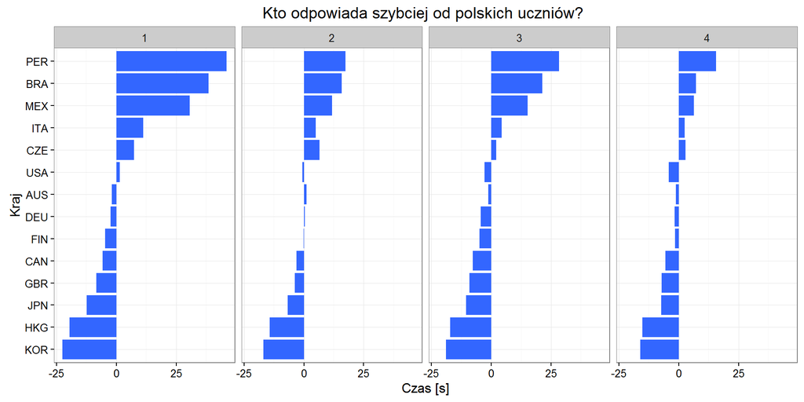

Niezależnie od pozycji pod względem czasu, polskim uczniom najdalej jest do młodzieży krajów azjatyckich. Osiągamy lepsze czasy niż nasz południowy sąsiad - Czechy, jednak różnica ta maleje w trakcie testu. Natomiast dla zachodniego sąsiada, Niemiec, różnice są małe z jednym wyjątkiem - pozycji 3 na naszą niekorzyść.

Mając punkt odniesienia, nie jest trudno wyobrazić sobie jak będzie wyglądał ranking krajów pod względem czasu. Oczywiście najszybciej odpowiadają uczniowie z państw azjatyckich, w połowie stawki plasują się kraje Europy, Ameryki Północnej i Australia, a najdłużej odpowiadają uczniowie z Ameryki Południowej.

# 5. Wykonany kod

```r
library("dplyr")
library("ggplot2")
library("openxlsx")
library("stringi")
library("matrixStats")
library("plotly")

load("finalS.RData")
load("finalMR.RData")

data<-rbind(finalMR, finalS)

data<-data %>% mutate(exercise=stri_sub(item_short, 1,1), timing=timing/1000)

data$result<-ifelse(data$result=="No credit", 0, ifelse(data$result=="Partial credit", 1,2))

stat<-data %>% group_by(CNT, exercise, position) %>%
  summarize(minresult=min(result),
            medresult_W=weightedMedian(result,W_FSTUWT),
            medresult=median(result),
            meanresult=round(weighted.mean(result, W_FSTUWT),2),
            maxresult=max(result),
            minActions=min(n.actions),
            medActions=median(n.actions),
            meanActions=round(weighted.mean(n.actions, W_FSTUWT),2),
            maxActions=max(n.actions),
            minTiming=min(timing),
            medTiming_W=weightedMedian(timing,W_FSTUWT),
            medTiming=median(timing),
            meanTiming=round(weighted.mean(timing, W_FSTUWT),2),
            maxTiming=max(timing))%>%mutate_if(is.factor, as.character) %>% as.data.frame()

stat <- stat %>% mutate(exercise=ifelse(exercise=="M","Matematyka", ifelse(exercise=="R", "Czytanie ze zrozumieniem", "Nauki przyrodnicze")))
stat<-stat %>% mutate(CNT=stri_trim(CNT))

save(stat, file="stat_position.RData")
write.xlsx(stat, file="stat_position.xlsx")

#I wykres
ggplot(stat, aes(x=factor(position), y=meanTiming))+
  geom_violin(fill="#3366FF")+
  geom_boxplot(width = 0.1,outlier.shape = NA)+
  geom_point(data=subset(stat, CNT=="POL" | CNT=="PER" | CNT=="KOR"),
             aes(factor(position),meanTiming,label=CNT)) +
  geom_text(data=subset(stat, CNT=="POL" | CNT=="PER" | CNT=="KOR"  ),
            aes(factor(position),meanTiming,label=CNT))+
  facet_grid(.~exercise)+
  xlab("Pozycja")+
  ylab("Czas [s]")+
  theme_bw()+
  ylim(c(30,150))

#II wykres
stat2<-stat %>% filter(CNT %in% c("POL", "GBR", "FIN", "DEU", "HKG", "JPN", "KOR", "USA", "MEX", "PER", "BRA", "CAN", "AUS", "ITA","CZE") ) %>% select (CNT, exercise, position, meanTiming )
g<-ggplot(stat2, aes(x=position, y=meanTiming, col=CNT))+
  geom_line()+
  facet_grid(.~exercise)+
  theme_bw()+
  xlab("Pozycja")+
  ylab("Czas [s]")
g %>% ggplotly(originalData = FALSE, legend=FALSE)

#III wykres
roznica<-c(0,diff(stat2$meanTiming))
stat2$roznica<-roznica*(-1)

stats<-stat2[which(stat2$position==2 | stat2$position==4),]
stats<-stats %>% mutate(pozycja=ifelse(position==2, "1-2","3-4"))

rank<-stats %>% filter(position==2, exercise=="Czytanie ze zrozumieniem") %>% select(CNT, roznica)
rank<-rank[order(rank$roznica, decreasing = T),]

g<-ggplot(stats, aes(x=factor(CNT, levels=rank$CNT), y=roznica, fill=pozycja,
                     text =paste("Kraj:", CNT)))+
  geom_bar(stat="identity",position="dodge")+
  facet_grid( exercise~.) +
  ggtitle("Różnica w średnich czasach na pozycjach 1 i 2 oraz 3 i 4")+
  ylab("Czas [s]")+
  xlab("Kraj")+
  theme_bw()

g %>% ggplotly(originalData = FALSE,tooltip=c("text", "roznica", "pozycja"), legend=FALSE)

# IV wykres
statP<-data %>% group_by(position, CNT) %>%
  summarize(meanTiming=round(weighted.mean(timing, W_FSTUWT),2))%>%mutate_if(is.factor, as.character) %>% as.data.frame()

statP %>% mutate(CNT=stri_trim(CNT))

save(statP, file="statystyki_pozycja_kraj.RData")
write.xlsx(stat, file="statystyki_pozycja_kraj.xlsx")

stat2<-statP %>% filter(CNT %in% c("POL", "GBR", "FIN", "DEU", "HKG", "JPN", "KOR", "USA", "MEX", "PER", "BRA", "CAN", "AUS", "ITA","CZE") )

stat2$meanTiming2<-ifelse(stat2$position==1,stat2[stat2$position==1,3]-stat2[stat2$position==1 & stat2$CNT=="POL",3],
                          ifelse(stat2$position==2,stat2[stat2$position==2,3]-stat2[stat2$position==2 & stat2$CNT=="POL",3],
                                 ifelse(stat2$position==3,stat2[stat2$position==3,3]-stat2[stat2$position==3 & stat2$CNT=="POL",3],
                                        stat2[stat2$position==4,3]-stat2[stat2$position==4 & stat2$CNT=="POL",3])))


rank<-stat2 %>% filter(position==1, CNT != "POL") %>% select(CNT, meanTiming2)
rank<-rank[order(rank$meanTiming2, decreasing = F),]

ggplot(stat2[stat2$CNT!="POL",], aes(x=factor(CNT, levels=rank$CNT ),
                                     y=meanTiming2))+
  geom_bar(stat="identity", fill="#3366FF")+
  facet_grid(.~position)+
  coord_flip()+
  xlab("Kraj")+
  ylab("Czas [s]") +
  ggtitle("Kto odpowiada szybciej od polskich uczniów? ")+
  theme_bw()
```